# Time Series Basics

M. Affouf

April 6, 2018

# Time series

How fast is global warming occurring, and what will the impact be in 10 years?

In a **cross-sectional** dataset, variables are measured at a single point in time. In contrast, **longitudinal** data involves measuring variables repeatedly over time.

we’ll examine observations that have been recorded at regularly spaced time intervals for a given span of time. We can arrange observations such as these into a time series of the form `Y1, Y2, Y3, . , Yt, ., YT`, where `Yt` represents the value of `Y` at time `t` and `T` is the total number of observations in the series.

Consider two very different time series displayed in figure.

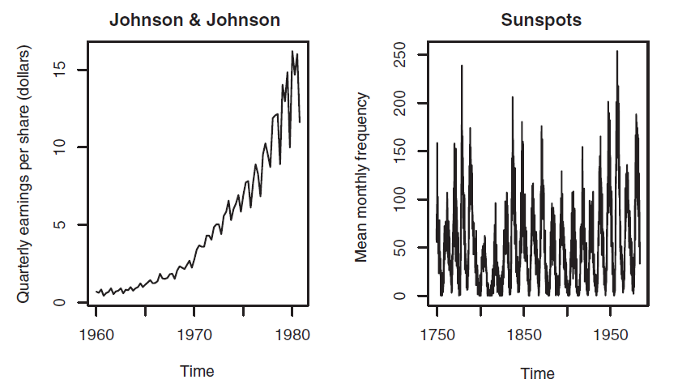

The series on the left contains the quarterly earnings (dollars) per Johnson & Johnson share between 1960 and 1980. There are 84 observations: one for each quarter over 21 years.

The series on the right describes the monthly mean relative sunspot numbers from 1749 to 1983 recorded by the Swiss Federal Observatory and the Tokyo Astronomical Observatory. The sunspots time series is much longer, with 2,820 observations- 1 per month for 235 years.

Studies of time-series data involve two fundamental questions:

what happened **(description)**, and what will happen next **(forecasting)**?

For the Johnson & Johnson data, you might ask

- Is the price of Johnson & Johnson shares changing over time?
- Are there quarterly effects, with share prices rising and falling in a regular fashion throughout the year?
- Can you forecast what future share prices will be and, if so, to what degree of accuracy?

For the sunspot data, you might ask

- What statistical models best describe sunspot activity?
- Do some models fit the data better than others?
- Are the number of sunspots at a given time predictable and, if so, to what degree?

Predicting future values of a time series, or **forecasting**, is a fundamental human activity, and studies of time series data have important real-world applications. **Economists** use time-series data in an attempt to understand and predict what will happen in **financial markets**. **City planners** use time-series data to predict future transportation demands. **Climate scientists** use time-series data to study global climate change. Corporations use time series to predict product demand and future sales. **Healthcare officials** use time-series data to study the spread of disease and to predict the number of future cases in a given region. **Seismologists** study times-series data in order to predict earthquakes.

### Functions for time-series analysis

| Function | Package | Use |
| --- | --- | --- |
| ts() | stats | Creates a time-series object. |
| plot() | graphics | Plots a time series. |
| start() | stats | Returns the starting time of a time series. |
| end() | stats | Returns the ending time of a time series. |
| frequency() | stats | Returns the period of a time series. |
| window() | stats | Subsets a time-series object. |
| ma() | forecast | Fits a simple moving-average model. |
| stl() | stats | Decomposes a time series into seasonal, trend, and irregular components using loess. |
| monthplot() | stats | Plots the seasonal components of a time series. |
| seasonplot() | forecast | Generates a season plot. |
| HoltWinters() | stats | Fits an exponential smoothing model. |
| forecast() | forecast | Forecasts future values of a time series. |
| accuracy() | forecast | Reports fit measures for a time-series model. |
| ets() | forecast | Fits an exponential smoothing model. Includes the ability to automate the selection of a model. |
| lag() | stats | Returns a lagged version of a time series. |
| Acf() | forecast | Estimates the autocorrelation function. |
| Pacf() | forecast | Estimates the partial autocorrelation function. |
| diff() | base | Returns lagged and iterated differences. |
| ndiffs() | forecast | Determines the level of differencing needed to remove trends in a time series. |
| adf.test() | tseries | Computes an Augmented Dickey-Fuller test that a time series is stationary. |
| arima() | stats | Fits autoregressive integrated moving-average models. |
| Box.test() | stats | Computes a Ljung-Box test that the residuals of a time series are independent. |
| bds.test() | tseries | Computes the BDS test that a series consists of independent, identically distributed random variables. |
| auto.arima() | forecast | Automates the selection of an ARIMA model. |

### Datasets

| Time series | Description |
| --- | --- |
| AirPassengers | Monthly airline passenger numbers from 1949-1960 |
| JohnsonJohnson | Quarterly earnings per Johnson & Johnson share |
| nhtemp | Average yearly temperatures in New Haven, Connecticut, from 1912-1971 |
| Nile | Flow of the river Nile |
| sunspots | Monthly sunspot numbers from 1749-1983 |

We’ll start with methods for creating and manipulating time series, describing and plotting them, and decomposing them into level, trend, seasonal, and irregular (error) components. Then we’ll turn to forecasting, starting with popular exponential modeling approaches that use weighted averages of time-series values to predict future values. Next we’ll consider a set of forecasting techniques called autoregressive integrated moving averages (ARIMA) models that use correlations among recent data points and among recent prediction errors to make future forecasts.

### Creating a time-series object in R

In order to work with a time series in R, you have to place it into a time-series object-an R structure that contains the observations, the starting and ending time of the series and information about its periodicity (for example, monthly, quarterly, or annual data). Once the data are in a time-series object, you can use numerous functions to manipulate, model, and plot the data.

`myseries <- ts(data, start=, end=, frequency=)`

for example, frequency=1 for annual data, frequency=12 for monthly data, and frequency=4 for quarterly data

An example is given in the following listing. The data consist of monthly sales figures for two years, starting in January 2003.

```r
sales <- c(18, 33, 41,  7, 34, 35, 24, 25, 24, 21, 25, 20,
           22, 31, 40, 29, 25, 21, 22, 54, 31, 25, 26, 35)
tsales <- ts(sales, start=c(2003, 1), frequency=12)
tsales
```

```
##      Jan Feb Mar Apr May Jun Jul Aug Sep Oct Nov Dec
## 2003  18  33  41   7  34  35  24  25  24  21  25  20
## 2004  22  31  40  29  25  21  22  54  31  25  26  35
```

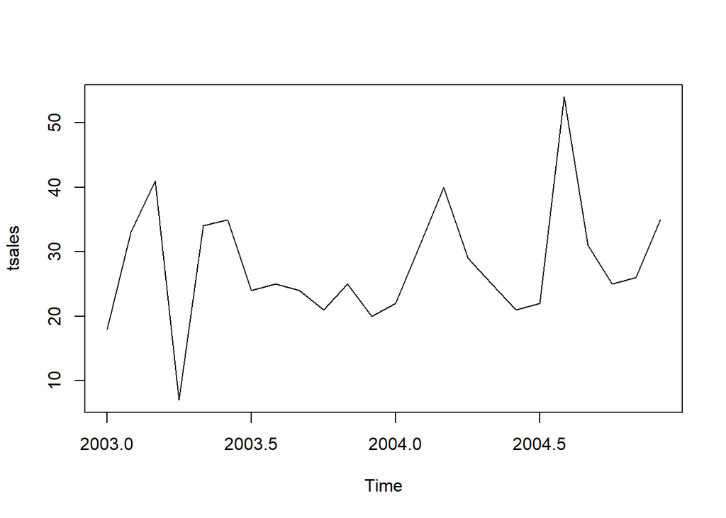

```r
plot(tsales)
```

### Smoothing with simple moving averages

The first step when investigating a time series is to plot it, Consider the Nile time series. It records the annual flow of the river Nile at Ashwan from 1871-1970. A plot of the series can be seen in the upper-left panel of figure.

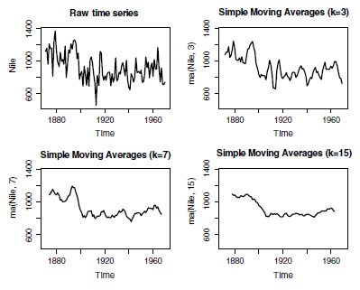

```r
# Simple moving averages
library(forecast)
```

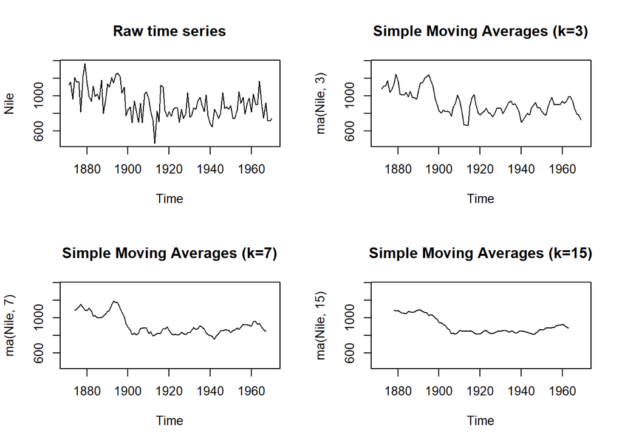

```r
opar <- par(no.readonly=TRUE)
par(mfrow=c(2,2))
ylim <- c(min(Nile), max(Nile))
plot(Nile, main="Raw time series")
plot(ma(Nile, 3), main="Simple Moving Averages (k=3)", ylim=ylim)
plot(ma(Nile, 7), main="Simple Moving Averages (k=7)", ylim=ylim)
plot(ma(Nile, 15), main="Simple Moving Averages (k=15)", ylim=ylim)
```

```r
par(opar)
```

The time series appears to be decreasing, but there is a great deal of variation from year to year. Time series typically have a significant irregular or error component. In order to discern any patterns in the data, you’ll frequently want to plot a smoothed curve that damps down these fluctuations. One of the simplest methods of smoothing a time series is to use `simple moving averages`. For example, each data point can be replaced with the mean of that observation and one observation before and after it. This is called a centered moving average. A centered moving average is defined as `St = (Yt-q + . + Yt + . + Yt+q) / (2q + 1)` where St is the smoothed value at time t and `k = 2q + 1` is the number of observations that are averaged. The k value is usually chosen to be an odd number (3 in this example). By necessity, when using a centered moving average, you lose the `(k - 1) / 2` observations at each end of the series.

### Seasonal decomposition

Time-series data that have a seasonal aspect (such as monthly or quarterly data) can be decomposed into a `trend component, a seasonal component, and an irregular component`. The `trend` component captures changes in level over time. The `seasonal` component captures cyclical effects due to the time of year. The `irregular` (or error) component captures those influences not described by the trend and seasonal effects. The decomposition can be `additive` or `multiplicative`. In an additive model, the components sum to give the values of the time series. Specifically,

`Y_t = Trend_t + Seasonal_t + Irregular_t`

where the observation at time t is the sum of the contributions of the trend at time t, the seasonal effect at time t, and an irregular effect at time t.

In a multiplicative model, given by the equation `Yt = Trend_t * Seasonal_t * Irregular_t`

the trend, seasonal, and irregular influences are multiplied. Examples are given in figure

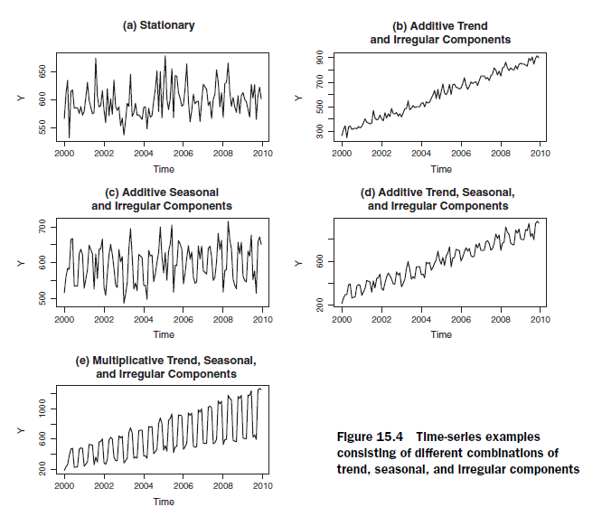

In the first plot (a), there is neither a trend nor a seasonal component. The only influence is a random fluctuation around a given level. In the second plot (b), there is an upward trend over time, as well as random fluctuations. In the third plot (c), there are seasonal effects and random fluctuations, but no overall trend away from a horizontal line. In the fourth plot (d), all three components are present: an upward trend, seasonal effects, and random fluctuations. You also see all three components in the final plot (e), but here they combine in a multiplicative way. Notice how the variability is proportional to the level: as the level increases, so does the variability. This amplification (or possible damping) based on the current level of the series strongly suggests a multiplicative model.

A popular method for decomposing a time series into `trend, seasonal, and irregular` components is seasonal decomposition by loess smoothing. In R, this can be accomplished with the `stl()` function. The format is  
`stl(ts, s.window=, t.window=)`

where `ts` is the time series to be decomposed, `s.window` controls how fast the seasonal effects can change over time, and `t.window` controls how fast the trend can change over time. Smaller values allow more rapid change. Setting `s.window="periodic"` forces seasonal effects to be identical across years. Only the `ts` and `s.window` parameters are required. See help(stl) for details.

The `stl() function can only handle additive models, but this isn't a serious limitation. Multiplicative models can be transformed into additive models using a log transformation:`log(Y_t) = log(Trend_t * Seasonal_t * Irregular_t)`

`= log(Trend_t) + log(Seasonal_t) + log(Irregular_t)`

After fitting the additive model to the log transformed series, the results can be backtransformed to the original scale. Let’s look at an example.

The time series `AirPassengers` comes with a base R installation and describes the monthly totals (in thousands) of international airline passengers between 1949 and 1960. A plot of the data is given in the top of figure. From the graph, it appears that variability of the series increases with the level, suggesting a multiplicative model.

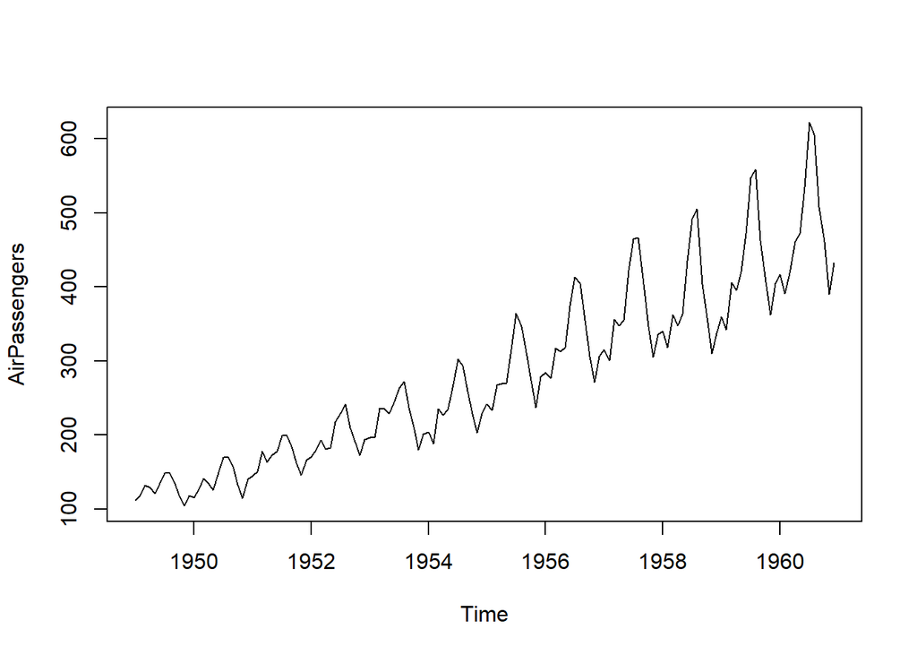

```r
# Listing 15.3 - Seasonal decomposition using slt()
plot(AirPassengers)
```

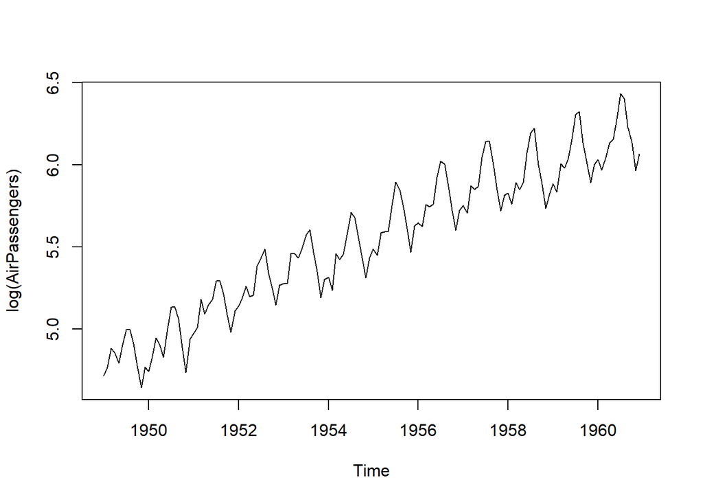

```r
lAirPassengers <- log(AirPassengers)
plot(lAirPassengers, ylab="log(AirPassengers)")
```

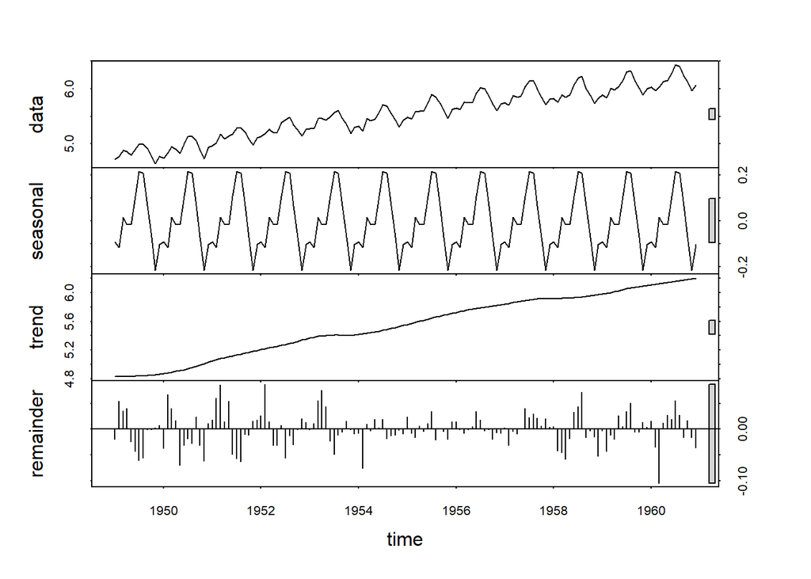

```r
fit <- stl(lAirPassengers, s.window="period")
plot(fit)
```

```r
head(fit$time.series)
```

```
##             seasonal    trend   remainder
## Jan 1949 -0.09164042 4.829389 -0.01924936
## Feb 1949 -0.11402828 4.830368  0.05434477
## Mar 1949  0.01586585 4.831348  0.03558845
## Apr 1949 -0.01402759 4.833377  0.04046325
## May 1949 -0.01502478 4.835406 -0.02459053
## Jun 1949  0.10978976 4.838166 -0.04268143
```

```r
head(exp(fit$time.series))
```

```
##           seasonal    trend remainder
## Jan 1949 0.9124332 125.1344 0.9809347
## Feb 1949 0.8922327 125.2571 1.0558486
## Mar 1949 1.0159924 125.3798 1.0362293
## Apr 1949 0.9860703 125.6345 1.0412930
## May 1949 0.9850875 125.8897 0.9757094
## Jun 1949 1.1160434 126.2377 0.9582166
```

The object returned by the stl() function contains a component called time.series that contains the trend, season, and irregular portion of each observation d. In this case, fit$time.series is based on the logged time series. exp(fit$time.series) converts the decomposition back to the original metric. Examining the seasonal effects suggests that the number of passengers increased by 24% in July (a multiplier of 1.24) and decreased by 20% in November (with a multiplier of .80). Two additional graphs can help to visualize a seasonal decomposition. They’re created by the monthplot() function that comes with base R and the seasonplot() function provided in the forecast package. The code

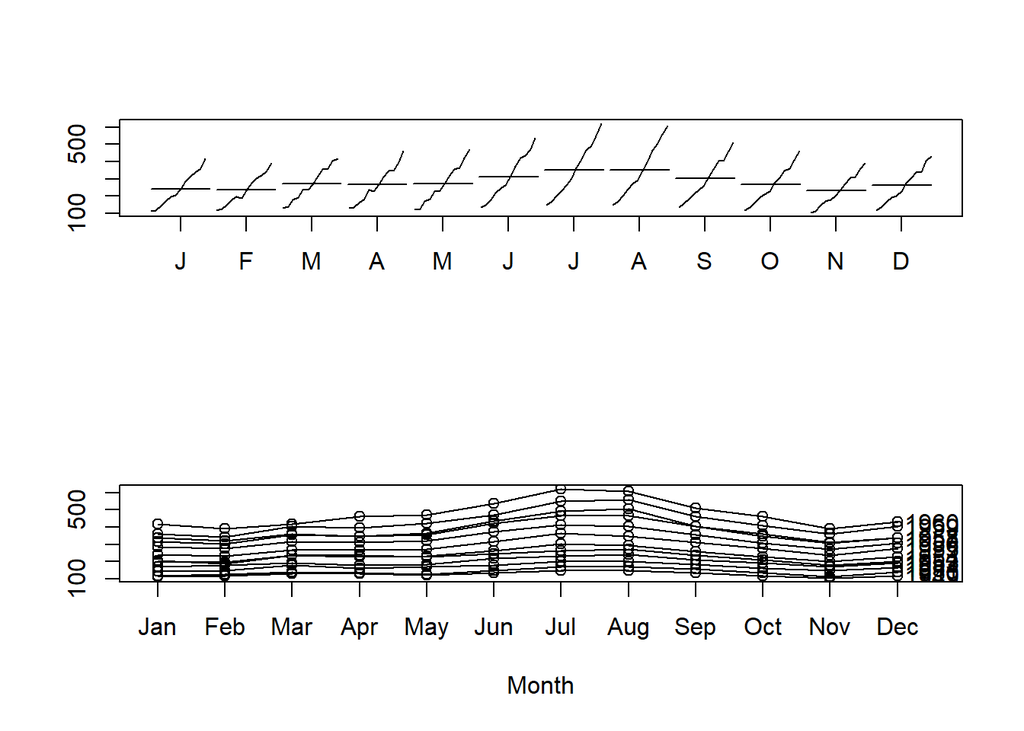

```r
par(mfrow=c(2,1))
library(forecast)
monthplot(AirPassengers, xlab="",  ylab="")
seasonplot(AirPassengers, year.labels="TRUE", main="")
```

```r
par(opar)
```

### Exponential forecasting models

Exponential models are some of the most popular approaches to forecasting the future values of a time series. They’re simpler than many other types of models, but they can yield good short-term predictions in a wide range of applications. They differ from each other in the components of the time series that are modeled. A simple exponential model (also called a single exponential model) fits a time series that has a constant level and an irregular component at time i but has neither a trend nor a seasonal component. A double exponential model (also called a Holt exponential smoothing) fits a time series with both a level and a trend. Finally, a triple exponential model (also called a Holt-Winters exponential smoothing) fits a time series with level, trend, and seasonal components. Exponential models can be fit with either the HoltWinters() function in the base installation or the ets() function that comes with the forecast package. The ets() function has more options and is generally more powerful. We’ll focus on the ets() function in this section. The format of the ets() function is

`ets(ts, model="ZZZ")`

### Simple exponential smoothing

Simple exponential smoothing uses a weighted average of existing time-series values to make a short-term prediction of future values. The weights are chosen so that observations have an exponentially decreasing impact on the average as you go back in time. The simple exponential smoothing model assumes that an observation in the time series can be described by

`Yt = level + irregulart`

```r
# Simple exponential smoothing
library(forecast)
fit <- HoltWinters(nhtemp, beta=FALSE, gamma=FALSE)
fit
```

```
## Holt-Winters exponential smoothing without trend and without seasonal component.
##
## Call:
## HoltWinters(x = nhtemp, beta = FALSE, gamma = FALSE)
##
## Smoothing parameters:
##  alpha: 0.1860813
##  beta : FALSE
##  gamma: FALSE
##
## Coefficients:
##       [,1]
## a 51.87641
```

```r
forecast(fit, 1)
```

```
##      Point Forecast    Lo 80    Hi 80    Lo 95    Hi 95
## 1972       51.87641 50.42279 53.33002 49.65329 54.09952
```

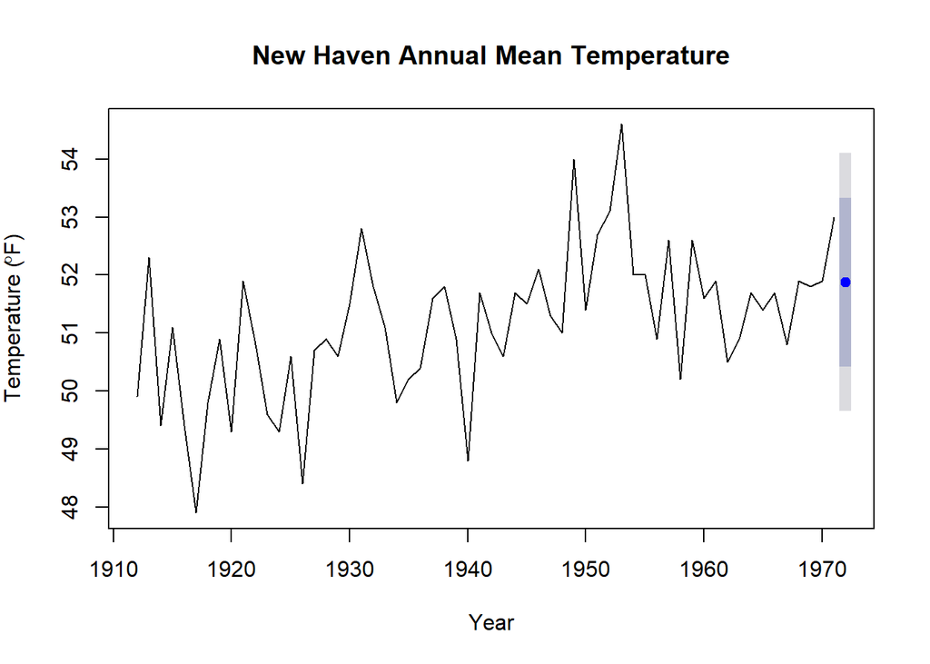

```r
plot(forecast(fit, 1), xlab="Year",
     ylab=expression(paste("Temperature (", degree*F,")",)),
     main="New Haven Annual Mean Temperature")
```

```r
#accuracy(fit)
```

### Holt and Holt-Winters exponential smoothing

The Holt exponential smoothing approach can fit a time series that has an overall level and a trend (slope). The model for an observation at time t is Yt = level + slope*t + irregulart An alpha smoothing parameter controls the exponential decay for the level, and a beta smoothing parameter controls the exponential decay for the slope. Again, each parameter ranges from 0 to 1, with larger values giving more weight to recent observations. The Holt-Winters exponential smoothing approach can be used to fit a time series that has an overall level, a trend, and a seasonal component. Here, the model is

`Yt = level + slope*t + st + irregulart`

```r
# Exponential smoothing with level, slope, and seasonal components
fit <- HoltWinters(log(AirPassengers))
fit
```

```
## Holt-Winters exponential smoothing with trend and additive seasonal component.
##
## Call:
## HoltWinters(x = log(AirPassengers))
##
## Smoothing parameters:
##  alpha: 0.3266015
##  beta : 0.005744138
##  gamma: 0.8206654
##
## Coefficients:
##             [,1]
## a    6.172308435
## b    0.008981893
## s1  -0.073201087
## s2  -0.140973564
## s3  -0.036703294
## s4   0.014522733
## s5   0.032554237
## s6   0.154873570
## s7   0.294317062
## s8   0.276063997
## s9   0.088237657
## s10 -0.032657089
## s11 -0.198012716
## s12 -0.102863837
```

```r
#accuracy(fit)

pred <- forecast(fit, 5)
pred
```

```
##          Point Forecast    Lo 80    Hi 80    Lo 95    Hi 95
## Jan 1961       6.108089 6.057867 6.158312 6.031281 6.184898
## Feb 1961       6.049299 5.996436 6.102161 5.968452 6.130145
## Mar 1961       6.162551 6.107146 6.217956 6.077816 6.247285
## Apr 1961       6.222759 6.164896 6.280622 6.134265 6.311252
## May 1961       6.249772 6.189525 6.310019 6.157633 6.341912
```

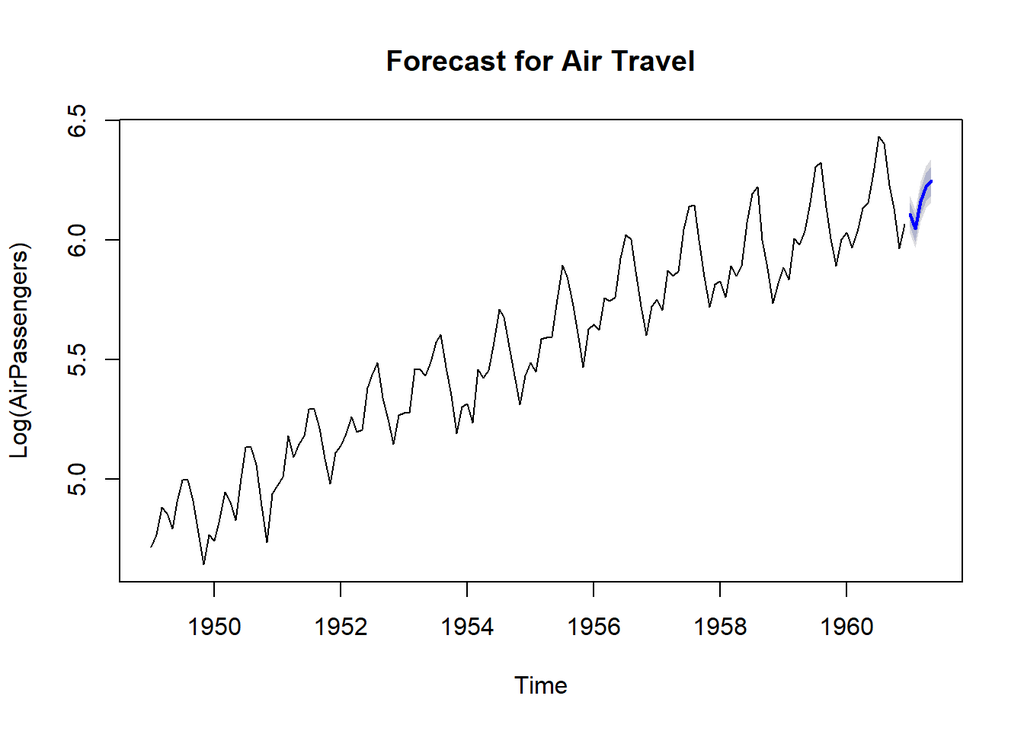

```r
plot(pred, main="Forecast for Air Travel",
     ylab="Log(AirPassengers)", xlab="Time")
```

```r
pred$mean <- exp(pred$mean)
pred$lower <- exp(pred$lower)
pred$upper <- exp(pred$upper)
p <- cbind(pred$mean, pred$lower, pred$upper)
dimnames(p)[[2]] <- c("mean", "Lo 80", "Lo 95", "Hi 80", "Hi 95")
p
```

```
##              mean    Lo 80    Lo 95    Hi 80    Hi 95
## Jan 1961 449.4790 427.4626 416.2477 472.6295 485.3634
## Feb 1961 423.8157 401.9936 390.9003 446.8224 459.5027
## Mar 1961 474.6372 449.0552 436.0759 501.6767 516.6085
## Apr 1961 504.0920 475.7516 461.3999 534.1206 550.7342
## May 1961 517.8948 487.6146 472.3087 550.0553 567.8808
```

### The ets() function and automated forecasting

The `ets()` function has additional capabilities. You can use it to fit exponential models that have multiplicative components, add a dampening component, and perform automated forecasts. Let’s consider each in turn. In the previous section, you fit an additive exponential model to the log of the `AirPassengers` time series. Alternatively, you could fit a multiplicative model to the original data. The function call would be either `ets(AirPassengers, model="MAM")`

or the equivalent `hw(AirPassengers, seasonal="multiplicative")`. The trend remains additive, but the seasonal and irregular components are assumed to be multiplicative. By using a multiplicative model in this case, the accuracy statistics and forecasted values are reported in the original metric (thousands of passengers)-a decided advantage. The `ets()` function can also fit a damping component. Time-series predictions often assume that a trend will continue up forever (housing market, anyone?). A damping component forces the trend to a horizontal asymptote over a period of time. In many cases, a damped model makes more realistic predictions. Finally, you can invoke the ets() function to automatically select a best-fitting model for the data. Let’s fit an automated exponential model to the Johnson & Johnson data described in the introduction to this chapter. The following code allows the software to select a best-fitting model.

```r
# Automatic exponential forecasting with ets()
library(forecast)
fit <- ets(JohnsonJohnson)
fit
```

```
## ETS(M,A,M)
##
## Call:
##  ets(y = JohnsonJohnson)
##
##   Smoothing parameters:
##     alpha = 0.1481
##     beta  = 0.0912
##     gamma = 0.4908
##
##   Initial states:
##     l = 0.6146
##     b = 0.005
##     s=0.692 1.2644 0.9666 1.077
##
##   sigma:  0.0889
##
##      AIC     AICc      BIC
## 166.6964 169.1289 188.5738
```

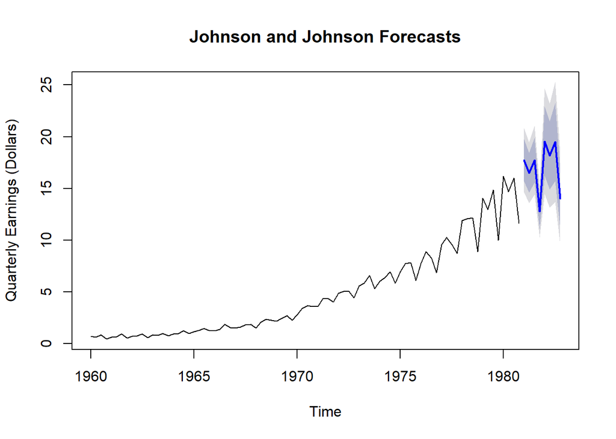

```r
plot(forecast(fit), main="Johnson and Johnson Forecasts",
     ylab="Quarterly Earnings (Dollars)", xlab="Time")
```

## ARIMA forecasting models

In the autoregressive integrated moving average (ARIMA) approach to forecasting, predicted values are a linear function of recent actual values and recent errors of prediction (residuals). ARIMA is a complex approach to forecasting. In this section, we’ll limit discussion to ARIMA models for non-seasonal time series.

### ARMA and ARIMA models

In an autoregressive model of order p, each value in a time series is predicted from a linear combination of the previous p values

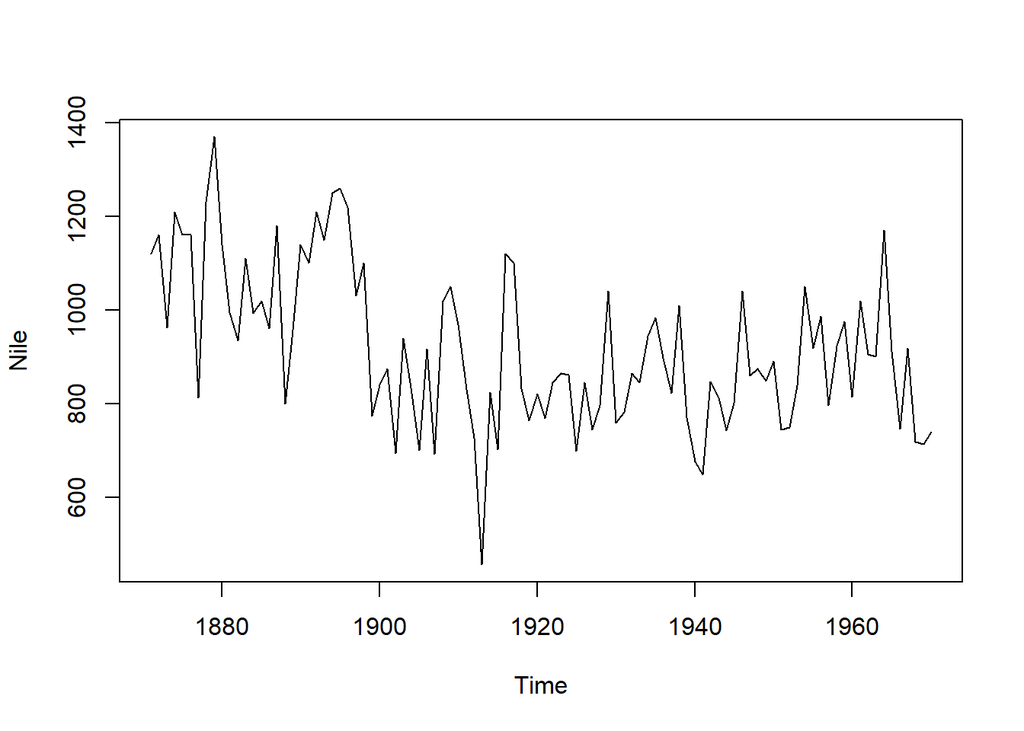

```r
# Transforming the time series and assessing stationarity
library(forecast)
library(tseries)
plot(Nile)
```

```r
ndiffs(Nile)
```

```
## [1] 1
```

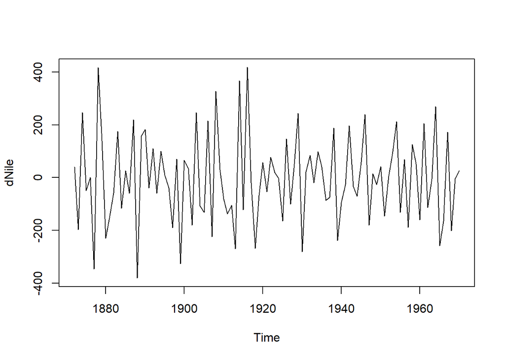

```r
dNile <- diff(Nile)
plot(dNile)
```

```r
adf.test(dNile)
```

```
##
##  Augmented Dickey-Fuller Test
##
## data:  dNile
## Dickey-Fuller = -6.5924, Lag order = 4, p-value = 0.01
## alternative hypothesis: stationary
```

### FITTING THE MODEL(S)

The ARIMA model is fit with the arima() function. The format is arima(ts, order=c(q, d, q)). The result of fitting an ARIMA(0, 1, 1) model to the Nile time series is given in the following listing.

```r
#  Fit an ARIMA model
fit <- arima(Nile, order=c(0,1,1))
fit
```

```
##
## Call:
## arima(x = Nile, order = c(0, 1, 1))
##
## Coefficients:
##           ma1
##       -0.7329
## s.e.   0.1143
##
## sigma^2 estimated as 20600:  log likelihood = -632.55,  aic = 1269.09
```

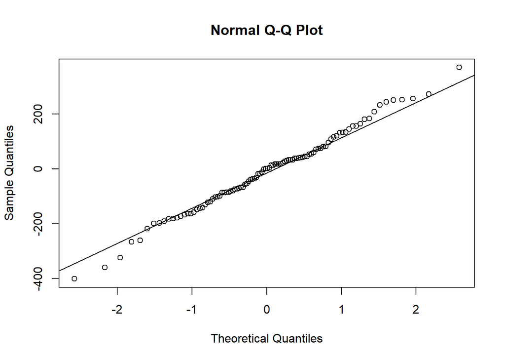

```r
#accuracy(fit)


# Evaluating the model fit
qqnorm(fit$residuals)
qqline(fit$residuals)
```

```r
Box.test(fit$residuals, type="Ljung-Box")
```

```
##
##  Box-Ljung test
##
## data:  fit$residuals
## X-squared = 1.3711, df = 1, p-value = 0.2416
```

```r
# Forecasting with an ARIMA model
forecast(fit, 3)
```

```
##      Point Forecast    Lo 80    Hi 80    Lo 95    Hi 95
## 1971       798.3673 614.4307 982.3040 517.0605 1079.674
## 1972       798.3673 607.9845 988.7502 507.2019 1089.533
## 1973       798.3673 601.7495 994.9851 497.6663 1099.068
```

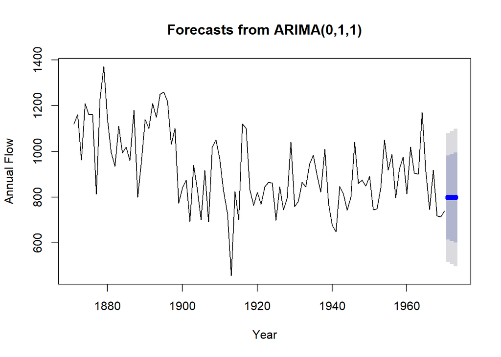

```r
plot(forecast(fit, 3), xlab="Year", ylab="Annual Flow")
```

```r
#  Automated ARIMA forecasting
library(forecast)
fit <- auto.arima(sunspots)
fit
```

```
## Series: sunspots
## ARIMA(2,1,2)
##
## Coefficients:
##          ar1      ar2      ma1     ma2
##       1.3467  -0.3963  -1.7710  0.8103
## s.e.  0.0303   0.0287   0.0205  0.0194
##
## sigma^2 estimated as 243.8:  log likelihood=-11745.5
## AIC=23500.99   AICc=23501.01   BIC=23530.71
```

```r
forecast(fit, 3)
```

```
##          Point Forecast    Lo 80    Hi 80    Lo 95    Hi 95
## Jan 1984       40.43772 20.42706 60.44839 9.834054 71.04139
## Feb 1984       41.35290 18.26320 64.44260 6.040252 76.66554
## Mar 1984       39.79642 15.23635 64.35650 2.235028 77.35782
```

```r
#accuracy(fit)
```